# Project: Medical Appointment No Shows

- Introduction
- Data Wrangling
- Dataset Description
- Data Cleaning
- Type Conversion
- Exploratory Data Analysis
- Initial Observations
- Which is weekday that patient commitment to the appointment or not?
- What is the gender who more fail to appear in a medical appointment?
- How receiving SMS will be affected the patient appointments attendance?
- What is patient age classification who recorded with the high no-show?
- Conclusions
- Project Limitations
- Summary

## Introduction

Healthcare expenses have cost a fortune. The average hourly pay of a physician is considered high regardless of the different salary structure around the globe. The cost of that time slot remains the same whether or not a patient missed his/her medical appointment.

In this project, the data associated with scheduled patient appointments will be analyzed. In particular, the findings from trends among the patients who no show and the others who attended a doctor appointment. This project aims to understand the possibility of predicting patients who fail to appear in a medical's appointment.

```python
import numpy as np
import pandas as pd
import matplotlib.pyplot as plt
import seaborn as sns
%matplotlib inline
```

## Data Wrangling

### Dataset Description

```python
df = pd.read_csv('KaggleV2-May-2016.csv')
df.head()
```

|  | PatientId | AppointmentID | Gender | ScheduledDay | AppointmentDay | Age | Neighbourhood | Scholarship | Hipertension | Diabetes | Alcoholism | Handcap | SMS_received | No-show |
| --- | --- | --- | --- | --- | --- | --- | --- | --- | --- | --- | --- | --- | --- | --- |
| 0 | 2.987250e+13 | 5642903 | F | 2016-04-29T18:38:08Z | 2016-04-29T00:00:00Z | 62 | JARDIM DA PENHA | 0 | 1 | 0 | 0 | 0 | 0 | No |
| 1 | 5.589978e+14 | 5642503 | M | 2016-04-29T16:08:27Z | 2016-04-29T00:00:00Z | 56 | JARDIM DA PENHA | 0 | 0 | 0 | 0 | 0 | 0 | No |
| 2 | 4.262962e+12 | 5642549 | F | 2016-04-29T16:19:04Z | 2016-04-29T00:00:00Z | 62 | MATA DA PRAIA | 0 | 0 | 0 | 0 | 0 | 0 | No |
| 3 | 8.679512e+11 | 5642828 | F | 2016-04-29T17:29:31Z | 2016-04-29T00:00:00Z | 8 | PONTAL DE CAMBURI | 0 | 0 | 0 | 0 | 0 | 0 | No |
| 4 | 8.841186e+12 | 5642494 | F | 2016-04-29T16:07:23Z | 2016-04-29T00:00:00Z | 56 | JARDIM DA PENHA | 0 | 1 | 1 | 0 | 0 | 0 | No |

```python
# rename column names
df.rename(columns={'PatientId':'Patient_ID','AppointmentID':'Appointment_ID','ScheduledDay':'Scheduled_Day','AppointmentDay':'Appointment_Day','Hipertension':'Hypertension','SMS_received':'SMS_Received','No-show':'No_Show'}, inplace=True)

# confirm changes
df.head(1)
```

|  | Patient_ID | Appointment_ID | Gender | Scheduled_Day | Appointment_Day | Age | Neighbourhood | Scholarship | Hypertension | Diabetes | Alcoholism | Handcap | SMS_Received | No_Show |
| --- | --- | --- | --- | --- | --- | --- | --- | --- | --- | --- | --- | --- | --- | --- |
| 0 | 2.987250e+13 | 5642903 | F | 2016-04-29T18:38:08Z | 2016-04-29T00:00:00Z | 62 | JARDIM DA PENHA | 0 | 1 | 0 | 0 | 0 | 0 | No |

```python
df.shape
```

```
(110527, 14)
```

| **Name** | **Value(s)** | **Description** |
| --- | --- | --- |
| Patient_ID | number | Identification of a patient |
| Appointment_ID | number | Identification of each appointment |
| Gender | F or M | Patient's sex. It's either Male or Female |
| Scheduled_Day | date | Indicates the day that patient registered the appointment |
| Appointment_Day | date | Indicates the appointment day that patient shows up |
| Age | number | Patient age |
| Neighbourhood | string | Where the appointment location |
| Scholarship | 0 or 1 | Indicates if the patient part of the Brazilian social welfare program or not |
| Hypertension | 0 or 1 | Indicates if the patient is Hypertension |
| Diabetes | 0 or 1 | Indicates if the patient is Diabetes |
| Alcoholism | 0 or 1 | Indicates if the patient is an alcoholic |
| Handcap | 0 or 1 | Indicates if the patient is handicapped |
| SMS_Received | 0 or 1 | Indicates if the patient received one or more notification messages or not |
| No_Show | Yes or No | Indicates if Yes means the patient missed the appointment or No (showed up) |

### Data Cleaning

#### Missing, Duplicate, Null and Unique Data

```python
# check if there are missing value in the dataset
df.info()
```

```
<class 'pandas.core.frame.DataFrame'>
RangeIndex: 110527 entries, 0 to 110526
Data columns (total 14 columns):
Patient_ID         110527 non-null float64
Appointment_ID     110527 non-null int64
Gender             110527 non-null object
Scheduled_Day      110527 non-null object
Appointment_Day    110527 non-null object
Age                110527 non-null int64
Neighbourhood      110527 non-null object
Scholarship        110527 non-null int64
Hypertension       110527 non-null int64
Diabetes           110527 non-null int64
Alcoholism         110527 non-null int64
Handcap            110527 non-null int64
SMS_Received       110527 non-null int64
No_Show            110527 non-null object
dtypes: float64(1), int64(8), object(5)
memory usage: 11.8+ MB
```

```python
# check if there are duplicates in the dataset
df.duplicated().sum()
```

```
0
```

```python
# check if there are null datas in the dataset
df.isnull().sum()
```

```
Patient_ID         0
Appointment_ID     0
Gender             0
Scheduled_Day      0
Appointment_Day    0
Age                0
Neighbourhood      0
Scholarship        0
Hypertension       0
Diabetes           0
Alcoholism         0
Handcap            0
SMS_Received       0
No_Show            0
dtype: int64
```

```python
# check the number of unique values in each column
df.nunique()
```

```
Patient_ID          62299
Appointment_ID     110527
Gender                  2
Scheduled_Day      103549
Appointment_Day        27
Age                   104
Neighbourhood          81
Scholarship             2
Hypertension            2
Diabetes                2
Alcoholism              2
Handcap                 5
SMS_Received            2
No_Show                 2
dtype: int64
```

There isn't any missing value in the dataset, it's clear that each column contain 110527 entries. The Appointment ID is the only unique data. There are no columns that are duplicated. Also, no null value in any row in dataset.

#### Type Conversion

The type of Patient_ID will be changed from float to int, the Scheduled_Day and Appointment_Day columns type should be changed to datetime

```python
# Convert Patient_ID from float to int
df['Patient_ID'] = df['Patient_ID'].astype('int64')
```

```python
# Convert Scheduled_Day and Appointment_Day to datetime
df['Scheduled_Day'] = pd.to_datetime(df['Scheduled_Day']).dt.date.astype('datetime64[ns]')
df['Appointment_Day'] = pd.to_datetime(df['Appointment_Day']).dt.date.astype('datetime64[ns]')
```

```python
# Check if all columns type that mentioned above are changed
df.info()
```

```
<class 'pandas.core.frame.DataFrame'>
RangeIndex: 110527 entries, 0 to 110526
Data columns (total 14 columns):
Patient_ID         110527 non-null int64
Appointment_ID     110527 non-null int64
Gender             110527 non-null object
Scheduled_Day      110527 non-null datetime64[ns]
Appointment_Day    110527 non-null datetime64[ns]
Age                110527 non-null int64
Neighbourhood      110527 non-null object
Scholarship        110527 non-null int64
Hypertension       110527 non-null int64
Diabetes           110527 non-null int64
Alcoholism         110527 non-null int64
Handcap            110527 non-null int64
SMS_Received       110527 non-null int64
No_Show            110527 non-null object
dtypes: datetime64[ns](2), int64(9), object(3)
memory usage: 11.8+ MB
```

## Exploratory Data Analysis

### Initial Observations

```python
df.describe()
```

|  | Patient_ID | Appointment_ID | Age | Scholarship | Hypertension | Diabetes | Alcoholism | Handcap | SMS_Received |
| --- | --- | --- | --- | --- | --- | --- | --- | --- | --- |
| count | 1.105270e+05 | 1.105270e+05 | 110527.000000 | 110527.000000 | 110527.000000 | 110527.000000 | 110527.000000 | 110527.000000 | 110527.000000 |
| mean | 1.474963e+14 | 5.675305e+06 | 37.088874 | 0.098266 | 0.197246 | 0.071865 | 0.030400 | 0.022248 | 0.321026 |
| std | 2.560949e+14 | 7.129575e+04 | 23.110205 | 0.297675 | 0.397921 | 0.258265 | 0.171686 | 0.161543 | 0.466873 |
| min | 3.921700e+04 | 5.030230e+06 | -1.000000 | 0.000000 | 0.000000 | 0.000000 | 0.000000 | 0.000000 | 0.000000 |
| 25% | 4.172614e+12 | 5.640286e+06 | 18.000000 | 0.000000 | 0.000000 | 0.000000 | 0.000000 | 0.000000 | 0.000000 |
| 50% | 3.173184e+13 | 5.680573e+06 | 37.000000 | 0.000000 | 0.000000 | 0.000000 | 0.000000 | 0.000000 | 0.000000 |
| 75% | 9.439172e+13 | 5.725524e+06 | 55.000000 | 0.000000 | 0.000000 | 0.000000 | 0.000000 | 0.000000 | 1.000000 |
| max | 9.999816e+14 | 5.790484e+06 | 115.000000 | 1.000000 | 1.000000 | 1.000000 | 1.000000 | 4.000000 | 1.000000 |

There are 13 independent variables and one dependent (no_show) in the dataset.

In regard to describing the table, the average age of the patients is 37 with 25% of them are below 18 and the majority are below 55.

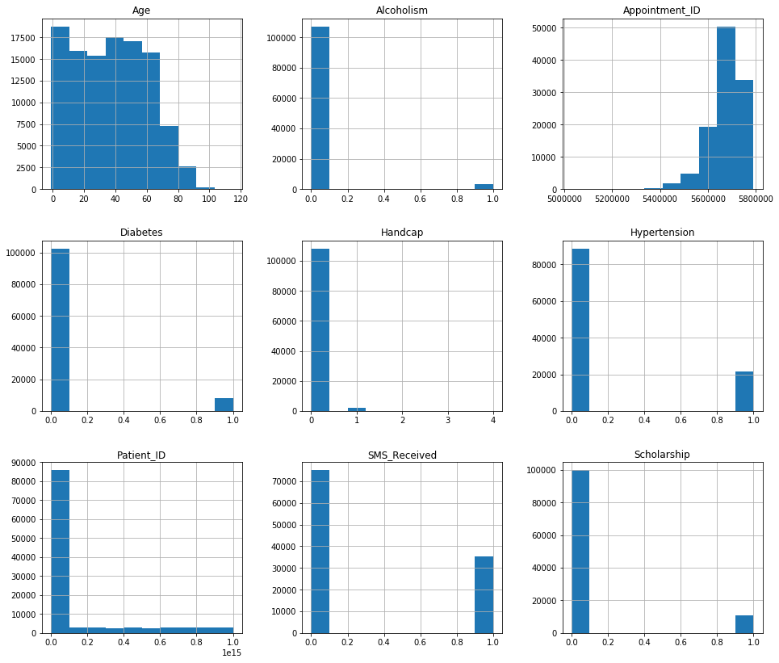

```python
df.hist(figsize=(16,14));
```

In histogram observations, most people ages in the dataset are below 40 years compared with the number of patients older than 60 years. The vast majority of people are not diabetes patients nor suffering from Hypertension or alcohol addiction, also most of the people not being handicapped. Most of the clinic visitors did not receive a prior SMS appointment. Moreover, most of the patients are not part of the Brazilian social welfare program.

```python
# calculate number of appointments
no_appointments = df['Appointment_ID'].nunique()
print('There are {} approved appointments'.format(no_appointments))

# Calculate rows where the patient Showed up and rows where they did not
no_show = df[df.No_Show == 'Yes']
number_no_show = no_show['No_Show'].count()
show_up = df[df.No_Show == 'No']
number_show_up = show_up['No_Show'].count()
print('There are {} patients that No Show'.format(number_no_show))
print('There are {} patients that Show Up'.format(number_show_up))
```

```
There are 110527 approved appointments
There are 22319 patients that No Show
There are 88208 patients that Show Up
```

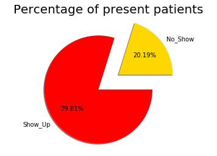

```python
# pie graph that shows the percentage of the patients Showed up or not
sizes = np.array([number_no_show, number_show_up])
labels = 'No_Show', 'Show_Up'
colors = ["gold", "red"]
explode = [0.7, 0]
plt.pie(sizes, labels = labels, colors = colors, explode = explode, shadow = True, autopct = '%.2f%%', radius = 1.5)
plt.title('Percentage of present patients', fontsize = 20, loc = 'center', color = 'k')
plt.axis('equal')
plt.show()
```

The Pie chart shows that more than 79% of patients attended their appointment whereas about 20% didn't show up.

### Q1: Which is weekday that patient commitment to the appointment or not?

```python
# Create appointment weekdays
df['appointment_weekdays'] = df.Appointment_Day.dt.weekday_name

# Check the values
no_appointments = df['appointment_weekdays'].value_counts()
print("The total appointments for every day of the week :\n", no_appointments)
```

```
The total appointments for every day of the week :
 Wednesday    25867
Tuesday      25640
Monday       22715
Friday       19019
Thursday     17247
Saturday        39
Name: appointment_weekdays, dtype: int64
```

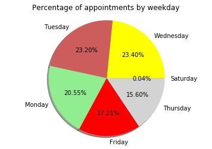

```python
# pie chart shows that the percentage of appointments by weekday
sizes = np.array(no_appointments)
labels = 'Wednesday', 'Tuesday', 'Monday', 'Friday', 'Thursday','Saturday'
colors = ['Yellow', 'indianred', 'LightGreen', 'Red', 'lightgrey', 'Pink']
explode = [0, 0, 0, 0, 0, 0]
plt.pie(sizes, labels = labels, colors = colors, explode = explode, shadow = True, autopct = '%.2f%%', radius = 0.8)
plt.title('Percentage of appointments by weekday')
plt.axis('equal')
plt.show()
```

```python
missed_weekday = df.query('No_Show == "Yes"')['appointment_weekdays'].value_counts()
print("The total patients who missed their appointment for every day of the week: \n", missed_weekday)
```

```
The total patients who missed their appointment for every day of the week:
 Tuesday      5152
Wednesday    5093
Monday       4690
Friday       4037
Thursday     3338
Saturday        9
Name: appointment_weekdays, dtype: int64
```

```python
appear_weekday = df.query('No_Show == "No"')['appointment_weekdays'].value_counts()
print("The total patients who showed up their appointment for every day of the week :\n", appear_weekday)
```

```
The total patients who showed up their appointment for every day of the week :
 Wednesday    20774
Tuesday      20488
Monday       18025
Friday       14982
Thursday     13909
Saturday        30
Name: appointment_weekdays, dtype: int64
```

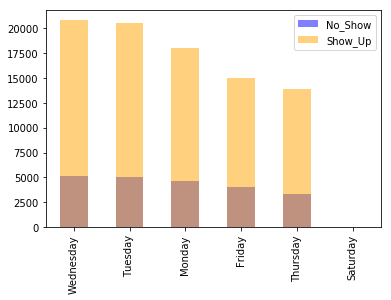

```python
missed_weekday.plot(kind='bar', alpha=0.5, color='blue', label='No_Show')
appear_weekday.plot(kind='bar', alpha=0.5, color='orange', label='Show_Up')
plt.legend();
```

It does look like the patients prefer to attend their appointment on Tuesday and Wednesday than other weekdays, of course, the same days recorded the highest numbers of patients no show. Overall, it appears that no day during the week much more effective for obligation appointment.

### Q2: What is the gender who more fail to appear in a medical appointment?

```python
# Function to calculate the percentage
def percentage(amount,total):
    pct = ((amount / total) * 100)
    return round(pct, 2)
```

```python
# number of genders
df.Gender.value_counts()
```

```
F    71840
M    38687
Name: Gender, dtype: int64
```

```python
# number of no show's for both Sex
total_noshow_sex = no_show['Gender'].count()
```

```python
# calculate the number of male gender who no show
male_missed = no_show['Gender'] == 'M'
no_male_missed = no_show[male_missed]['Gender'].count()
print("There are {} male patients didn't show up".format(no_male_missed))
```

```
There are 7725 male patients didn't show up
```

```python
# calculate the number of female gender who no show
female_missed = no_show['Gender'] == 'F'
no_female_missed = no_show[female_missed]['Gender'].count()
print("There are {} female patients didn't show up".format(no_female_missed))
```

```
There are 14594 female patients didn't show up
```

```python
# calculate the number of male patients who no show
print("{} percent of the male patients didn't show up".format(percentage(no_male_missed,total_noshow_sex)))
```

```
34.61 percent of the male patients didn't show up
```

```python
# calculate the number of female patients who no show
print("{} percent of the female patients didn't show up".format(percentage(no_female_missed,total_noshow_sex)))
```

```
65.39 percent of the female patients didn't show up
```

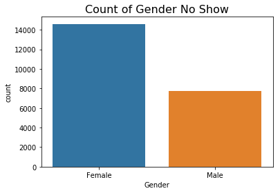

```python
ax = sns.countplot(no_show.Gender.replace({'F':'Female','M':'Male'}));
ax.set_title('Count of Gender No Show',fontsize=16);
```

There are definitely more women (65.39%) didn't show their appointment than men (34.61%).

### Q3: How receiving SMS will be affected the patient appointments attendance?

```python
# the total sms have been sent
sms_sent = df[df.SMS_Received == 1]
number_sms_sent = sms_sent['SMS_Received'].count()
number_sms_sent
```

```
35482
```

```python
total_appointments = df.query('SMS_Received == 0 or SMS_Received == 1').SMS_Received.value_counts()
print("The number of patient appointments whether receive sms or not: \n", total_appointments)

# count the number of patients who didn't notify by sms and show up
total_show_no_sms = df.query('No_Show == "No" and SMS_Received == 0').No_Show.value_counts()
print("The number of patients who didn't receive sms and show up :",total_show_no_sms)

print("The percentage of patients who showed up without receiving sms :", percentage(total_show_no_sms, 110527))
```

```
The number of patient appointments whether receive sms or not:
 0    75045
1    35482
Name: SMS_Received, dtype: int64
The number of patients who didn't receive sms and show up : No    62510
Name: No_Show, dtype: int64
The percentage of patients who showed up without receiving sms : No    56.56
Name: No_Show, dtype: float64
```

```python
# count the number of patients who notified by sms and showed up
total_show_sms = df.query('No_Show == "No" and SMS_Received == 1').No_Show.value_counts()
print("The number of patients who received sms and showed up :\n",total_show_sms)

# calculate the percentage of patients showed up with a recieved SMS
sms_shown = percentage(total_show_sms, number_sms_sent)

print("Patients who received SMS and showed up to the appointment {}".format(sms_shown.round(2)))
```

```
The number of patients who received sms and showed up :
 No    25698
Name: No_Show, dtype: int64
Patients who received SMS and showed up to the appointment No    72.43
Name: No_Show, dtype: float64
```

```python
# count the number of patients who notified by sms and didn't show
total_noshow_sms = df.query('No_Show == "Yes" and SMS_Received == 1').No_Show.value_counts()
print("The number of patients who received sms and didn't show up :",total_noshow_sms)

# calculate the percentage of patients didn't show with a recieved SMS
sms_nshown = percentage(total_noshow_sms, number_sms_sent)
print("Patients who received SMS and didn't show up {}".format(sms_nshown.round(2)))
```

```
The number of patients who received sms and didn't show up : Yes    9784
Name: No_Show, dtype: int64
Patients who received SMS and didn't show up Yes    27.57
Name: No_Show, dtype: float64
```

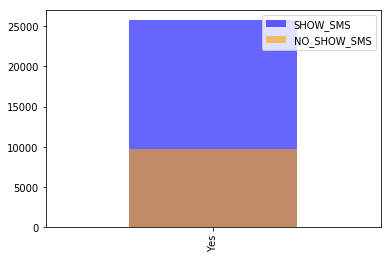

```python
# A bar plot shows the number of patients who received SMS notification and whether of showed up or no showed
total_show_sms.plot(kind='bar', alpha=0.6, color='blue', label='SHOW_SMS')
total_noshow_sms.plot(kind='bar', alpha=0.6, color='orange', label='NO_SHOW_SMS')
plt.legend();
```

### Q4: What is patient age classification who recorded with the high no-show?

```python
# create age_bins Via Defining Bin Edges to make age classification
df['age_bins'] = pd.cut(df['Age'], bins=[-1,0,10, 17, 18, 40, 41, 60, 61, 74, 75, 99, 120])
```

```python
# calculate the average patient ages who didn't show up
df.query('No_Show == "Yes"')['Age'].mean()
```

```
34.31766656212196
```

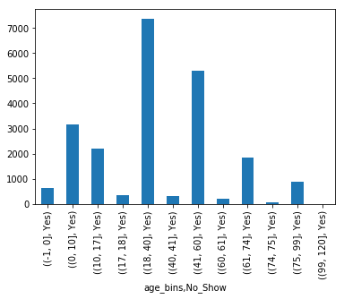

```python
# filter by no-shown appointments
no_shown_age = df.query('No_Show == "Yes"').groupby('age_bins').No_Show.value_counts()
no_shown_age.plot(kind='bar');
```

The most classification of patients age who missed their appointments are young adults(18 - 40)

```python
# create a query to find out the number of gender ages who missed their appointments
no_shown_age_gender = df.query('No_Show == "Yes"').groupby(['age_bins', 'Gender']).No_Show.value_counts()
no_shown_age_gender
```

```
age_bins   Gender  No_Show
(-1, 0]    F       Yes         319
           M       Yes         320
(0, 10]    F       Yes        1462
           M       Yes        1687
(10, 17]   F       Yes        1281
           M       Yes         928
(17, 18]   F       Yes         248
           M       Yes         102
(18, 40]   F       Yes        5338
           M       Yes        2037
(40, 41]   F       Yes         229
           M       Yes          79
(41, 60]   F       Yes        3641
           M       Yes        1642
(60, 61]   F       Yes         155
           M       Yes          45
(61, 74]   F       Yes        1279
           M       Yes         576
(74, 75]   F       Yes          56
           M       Yes          25
(75, 99]   F       Yes         583
           M       Yes         284
(99, 120]  F       Yes           3
Name: No_Show, dtype: int64
```

```python
# create a query to find out the number of female ages who missed their appointments
no_shown_age_f_gender = df.query('No_Show == "Yes" and Gender == "F"').groupby(['age_bins', 'Gender']).No_Show.value_counts()
```

```python
# create a query to find out the number of male ages who missed their appointments
no_shown_age_m_gender = df.query('No_Show == "Yes" and Gender == "M"').groupby(['age_bins', 'Gender']).No_Show.value_counts()
```

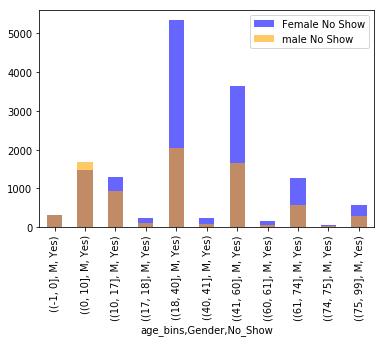

```python
# A bar plot shows the number of missing appointments for both men and women
no_shown_age_f_gender.plot(kind='bar', alpha=0.6, color='blue', label='Female No Show')
no_shown_age_m_gender.plot(kind='bar', alpha=0.6, color='orange', label='male No Show')
plt.legend();
```

The graph shows women are more than men for missing their appointments.

## Conclusions

### Project Limitations

In this project, four independent variables were compared to one dependent variable. However, there are many independent variables need to be studied and could be effective in final results and these are the following:

1. Neighbourhood column describes the appointment location. From initial observation, I noticed that the sample is lack of two important elements:

   a. Patient location and how far is it from appointment place.

   b. Patient's livelihood in this neighbourhood.
1. Scholarship column Indicates if the patient part of the Brazilian social welfare program or not, which I think studying this factor will be described the patient no-show behaviour when receiving a free service.
1. The patient health conditions could be a factor affecting their attendance. One of the important factor is handicapped people and their obstacles to reach the appointment because of mobility difficulties. Also, alcoholism causes discipline problems.
1. Gaps between scheduled visit time and appointment day could be affecting patient dissatisfaction and his/her obligation appointment.